# Model Identification in IRT and Factor Analysis Models

By Rick Farouni

#### *The Ohio State University*

04/23/2015

## Identification of the Likelihood

Consider the sampling distribution for a response $pi$ in a multidimensional IRT model given by $\begin{align}\label{MIRTlike} p(y_{pi}\vert{\boldsymbol{\theta}}_p,{\boldsymbol{\alpha}}_p,\beta_i)= {\biggl[\operatorname{logit}^{-1}\Bigl({\boldsymbol{\alpha}}^{\intercal}_{i}{\boldsymbol{\theta}}_{p}+\beta_{i} \Bigr)\biggr]}^{y_{pi}} {\biggl[1 - \operatorname{logit}^{-1}\Bigl({\boldsymbol{\alpha}}^{\intercal}_{i}{\boldsymbol{\theta}}_{p}+\beta_{i} \Bigr)\biggr]}^{1-y_{pi}} \end{align}$

The multiple unobservable parameters in the equation induce the problem of identification in the general data model. $\prod_{p=1}^P\ \prod_{i=1}^I\ p(y_{pi}\vert{\boldsymbol{\theta}}_p,{\boldsymbol{\alpha}}_i,\beta_i)$

### Additive and Multiplicative Aliasing

For the sake of illustration, consider a 1-dimensional IRT model with the linear predictor

$\begin{align*} \eta_{pi}=\alpha_{i}(\theta_{p}- \beta_{i}) \end{align*}$

If we add a constant $c_1$ to both $\theta_{p}$ and $\beta_i$ for all $p$’s, the likelihood still remains the same. Similarly, if we divide each $\alpha_{i}$ by another constant $c_2$ and multiply every pair $(\theta_{p}- \beta_{i})$ by the same constant, the likelihood also remains the same. That is, for any values of the constants $c_1$ and $c_2$, we have

$\begin{align*} p\left(y_{pi}\vert\theta_p,\alpha_i,\beta_i\right)=p\left(y_{pi}\vert (c_2\times(\theta_p+c_1)),\frac{\alpha_i}{c_2},(c_2\times(\beta_i+c_1))\right) \end{align*}$

One common method to mitigate this type of invariance works by assigning ${\boldsymbol{\theta}}_{p}$ a very strong prior (Bafumi et al. 2005), a fixed population distribution that can determine the location and scale of the parameter space for the entire likelihood function $p({\mathbf{y}}\vert{\boldsymbol{\theta}},{\boldsymbol{\alpha}},\boldsymbol\beta)$. The constraint is simply

$\begin{align*} &{\boldsymbol{\theta}}_p \sim \mathcal{Normal}_d(\textbf{0},\, \boldsymbol I) \quad \text{for } p=1,2,. . .,P \end{align*}$

### Reflection Invariance

If we multiply all the $\alpha_{i}$’s, $\theta_{p}$’s, and $\beta_{i}$’s by -1, we can still obtain the same likelihood. The resulting likelihood for a model that doesn’t add additional constraints will have a bi-modal density, with one mode obtained at positive parameter values and the reflected second mode obtained at the same but negative values. In the case of D dimensions, there are a total of $2^D$ possible sign reversals. For example, in two dimensions, the following are equivalent

$\begin{align*} &\theta^{(1)}\alpha^{(1)}+\alpha^{(2)}\theta^{(2)}\\ &(-\theta^{(1)})(-\alpha^{(1)})+(-\alpha^{(2)})(-\theta^{(2)})\\ &\theta^{(1)}\alpha^{(1)}+(-\alpha^{(2)})(-\theta^{(2)})\\ &(-\theta^{(1)})(-\alpha^{(1)})+\alpha^{(2)}\theta^{(2)} \end{align*}$

In the case of $D=1$, the solution to this problem is straightforward. The invariance is eliminated by choosing a direction. For example, in educational testing, the discrimination parameter is always assumed to be positive since a negative value implies that persons with high propensity would have a lower probability of answering correctly. Therefore, for the one dimensional IRT model, restricting one parameter $\alpha_{i}> 0$ and assigning a standard normal prior to ${\boldsymbol{\theta}}_{p}$ identifies the model. Alternatively, assigning the $\alpha_{i}$’s a lognormal prior can resolve reflection invariance $\begin{align*} {\boldsymbol{\alpha}}_i \sim & \mathit{LogNormal}(\boldsymbol\mu_{{\boldsymbol{\alpha}}},\,\boldsymbol\Sigma_{\alpha}) \quad \text{for } i=1,2,. . .,I \end{align*}$

There are other ways to specify a well-defined direction. For example, we can pin the first person’s propensity $\theta_{1}$ to 0 and pin the first item discrimination parameter $\alpha_{1}$ to 1. Now, the propensity of the other persons can be measured relative to the propensity of the first person and the discrimination of the other items, relative to the discrimination of the first item.

### Aliasing due to Label Switching

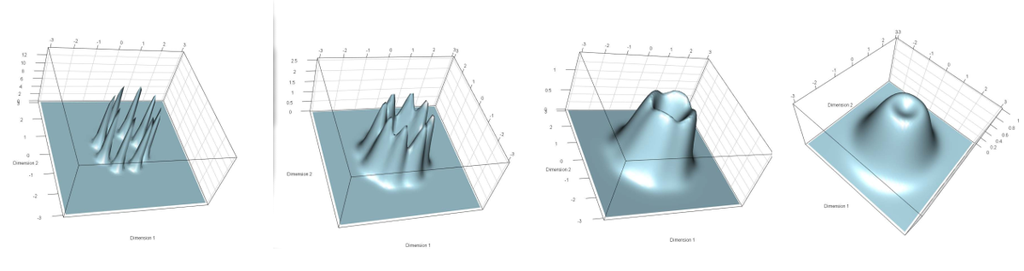

**Figure 1:** *The marginal posterior distribution of a two-dimensional parameter under different conditions of data informativeness: As the data becomes less informative and noisy, the components of the posterior distribution become increasingly indistinguishable*

### Rotation Invariance

Consider another concrete example. A simple two-dimensional model with item discrimination and person parameters only, so that for a particular person $p'$, the linear predictors are as follows:

$\begin{align*} \eta_{p'1}=&\theta^{(1)}_{p'}\alpha^{(1)}_1+\theta^{(2)}_{p'}\alpha^{(2)}_1\\ \eta_{p'2}=&\theta^{(1)}_{p'}\alpha^{(1)}_2+\theta^{(2)}_{p'}\alpha^{(2)}_2\\ \vdots \\ \eta_{p'I}=&\theta^{(1)}_{p'}\alpha^{(1)}_I+\theta^{(2)}_{p'}\alpha^{(2)}_I \end{align*}$

The likelihood for the corresponding model is invariant under rotation because we can find an orthogonal rotation matrix $\textbf{R}$, where $\textbf{R}^{\intercal}\textbf{R}=\textbf{I}$, such that when we rotate $\mathbf{A}$ and ${\boldsymbol{\theta}}$, we obtain two rotated matrices $\mathbf{A}^{\ast}=\mathbf{A}\textbf{R}^{\intercal}$ and ${\boldsymbol{\theta}}^{\ast}=\textbf{R}{\boldsymbol{\theta}}$ whose product gives us back the original matrices

$\begin{align*} \mathbf{A}^{\ast}{\boldsymbol{\theta}}^{\ast}=\mathbf{A}\textbf{R}^{\intercal}\textbf{R}{\boldsymbol{\theta}}=\mathbf{A}{\boldsymbol{\theta}}\end{align*}$

This webpage was created using the *R Markdown* authoring format and was generated using *knitr* dynamic report engine.

(C) 2015 Rick Farouni

References

Bafumi, Joseph, Andrew Gelman, David K. Park, and Noah Kaplan. 2005. “Practical Issues in Implementing and Understanding Bayesian Ideal Point Estimation.” *Political Analysis* 13: 171–87.

Gelman, Andrew, John B. Carlin, Hal Steven Stern, and Donald B. Rubin. 2014. *Bayesian Data Analysis*. Chapman & Hall/CRC.

Jackman, S. 2001. “Multidimensional Analysis of Roll Call Data via Bayesian Simulation: Identification, Estimation, Inference, and Model Checking.” *Political Analysis Political Analysis* 9: 227–41.